# Mini-Project 1. Feature Extraction and Transfer Learning

# VU Tuan-Anh (ID:20672378)

# Introduction

In this report, the comparison of Scattering Wavelet Transforms with Deep Neural Networks will be addresses. We will show the concept of symmetry and the importance of invariance in machine learning models, especially for signal processing applications (in this case handwritten digit recognition). The report compares the use of black box convolutional neural networks (in recent years, these models have been incredibly expressive in solving these problems) and the use of models caused by signal processing. The type of these problems is very important in signal processing: scattering wavelet transform.

In deep learning, a convolutional neural network (CNN, or ConvNet) is a class of deep neural networks, most commonly applied to analyzing visual imagery. They are also known as shift invariant or space invariant artificial neural networks (SIANN), based on their shared-weights architecture and translation invariance characteristics. They have applications in image and video recognition, recommender systems, image classification, medical image analysis, natural language processing, and financial time series.

The output of the convolution is usually fed to a so-called "detector" layer, which consists of a non-linear activation function, usually ReLU in most implementations. Where the kernel is inconsistent with the input, ReLU "turns off" the input. Therefore, the output tensor is much sparse. Then perform a downsampling operation on this output, which is called "merging". The pooling layer essentially down-samples the neighborhood by summarizing the output in the neighborhood into representative statistical data. It is said that this makes the network's transformation of the input flexible, depending on the size of the neighborhood under consideration. Later we will see that the wavelet scattering transform also uses pooling as one of the operations of translation invariance.

Wavelet scattering transform follow the spirit of decomposing the input function into a set of special basis functions that are invariant. Fourier transform attempts to decompose a function into Fourier basis, that is, to put it simply, try to express the function as a linear combination of Fourier basis functions, which is a complex sinusoid. Wavelet transform attempts to perform the same operation and decompose the function into wavelet basis. Both methods introduce some deformation invariance. Wavelet scattering attempts to decompose in a nonlinear way-as far as I know, it uses complex modulus functions as nonlinearities.

The rest of this report consists of following parts. Firstly, I will used VGG16 and ResNet18 pretrained on ImageNet as a fixed feature extractor for MNIST and a scattering wavelet transform on MNIST as another method of extracting deformation invariant features. In addition, I used Logistic regression and random forest for classification based on the extracted features. Finally, I will compare the results and provide high level explanation of the performance difference.

# Methodology and Implementation

### General description of the CNN is as follows:

- Use pretrained Alexnet, VGG16 and ResNet18 models from PyTorch
- Create modified versions of Alexnet, VGG16 and Resnet18 after removing the last fully connected layer from the architecture and use the output of the penultimate layer as extracted features. The initialization of the class constructs the architecture ommitting the last layer, if required. Forward function is updated to not pass the input through the last layer.
- Extract and save the MNIST dataset. According to the description, the default resolution of MNIST images are 28 x 28 pixels and the input sizes of ImageNet dataset is 3 x 224 x 224 where 3 indicates the RGB channel. Therefore, MNIST is transformed by scaling to 3 x 224 x 224.
- Push the transformed MNIST dataset through the networks with the shape of the features extracted from the models are as follows: AlexNet and VGG16 (60000, 4096), ResNet18 (60000, 512).
- Train and store the trained models based on extracted data. As stated before, we train Logistic Regression and Random Forests for this report. The code supports Gradient Boosting Trees also and can also easily be extended to SVMs. The code also supports choosing parameters using cross validation, however that was ommitted due to lack of enough compute resources.

### Wavelet Scattering Transform:

- The code uses wavelet scattering implementation from Kymatio which implements the wavelet scattering transform as a convolutional neural network. The documentation is hosted here: **kymat.io**
- The shape of the features from the wavelet scattering transform is (60000, 81, 7, 7) which is flattend to (60000, 3969)

### Implementations:

I have indeed perused the PyTorch official tutorials and some of the code might be inspired from those and also from other sources.

#### Visualization of the MNIST data

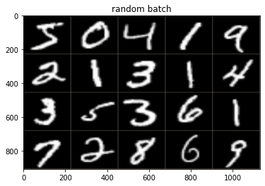

```python
import torch, torchvision
import sys, os
sys.path.append("../")
from utils import imshow
from torch.utils.data import DataLoader
from torchvision.utils import make_grid
from Dataset import TransformedMNIST

mnist = TransformedMNIST()
train_images = mnist.get_train()
dataloader = DataLoader(train_images, batch_size=20)
batch_id, images_w_labels = next(enumerate(dataloader))
images =  images_w_labels[0]
labels = images_w_labels[1]
image_grid = make_grid(images, nrow=5)

imshow(image_grid, title="random batch")
```

## tSNE Plot

Now let's load up the features extracted from each of the pretrained CNNs and make a tSNE plot of some random batches

The MNIST dataset from the above was pushed through modified versions of AlexNet, VGG16 and ResNet18 and were saved to disk, for the sake of time. If needed, the datasets can provided in order to run this notebook.

### AlexNet

From the tSNE plot below, one can easily deduce the relative "distances" or "similarities" between digits.

For instance, 2 lies very close to 5. 0 is close 6, and 4 & 7 are both close to 1.

This indicates that given a certain amount of deformation to any of the aforementioned digits, it is rather likely for them to morph into another digit in its neighborhood in the lower dimensional space.

```
reading from local directory
```

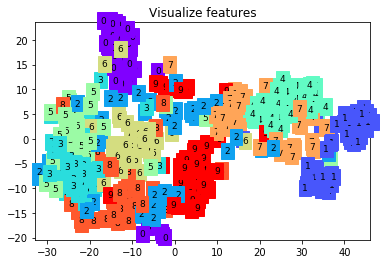

```python
# plot with tsne
from utils import visualize_tsne, get_stored_dataset
features, labels = get_stored_dataset("alexnet", train=True)
visualize_tsne(features, labels)
```

### VGG16

```
reading from local directory
```

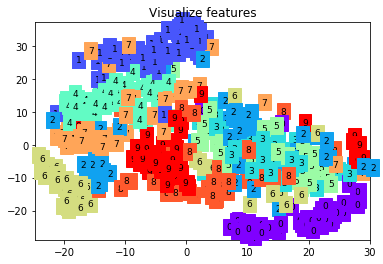

```python
# now we can use the utility function to load datasets
features, labels = get_stored_dataset("vgg16", train=True)
visualize_tsne(features, labels)
```

### ResNet

```
reading from local directory
```

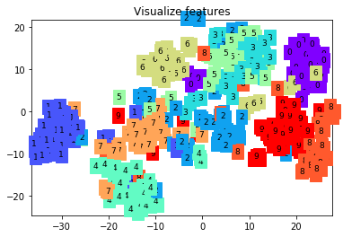

```python
features, labels = get_stored_dataset("resnet", train=True)
visualize_tsne(features, labels)
```

## Visualization of the features from the Wavelet Scattering transform

```
reading from local directory
```

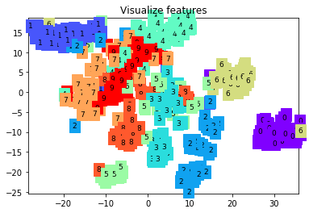

```python
features, labels = get_stored_dataset("scattering", train=True)
visualize_tsne(features, labels)
```

Purely based on the figures above, one would notice that the tSNE plot for the features extracted from the Wavelet Scattering transform, show the best separation between the classes, in the low dimensional space. Note that the tSNE visualizations that we run would only plot 500 points randomly, to reduce the time overhead.

## Models trained using the features above

Logistic Regression and Random Forests were trained as the pick for 1 linear and 1 non-linear model to use. Of course, as stated earlier, one could be more rigorous and include more such models to train and run cross validation to choose the best params, but the hope is that the gist of the analysis is captured by these two.

The models are already trained and stored on disk and is defined in `utils.py` in the function `train_classifier`. Similarly, in order to test the classifier, i.e. get predictions on one of the saved test datasets, we only need to change to `test_classifier`

In order to train logistic regression on features extracted from AlexNet, one could call the function as follows:

```
from utils import train_classifier
train_classifier("log_reg", dataset="alexnet", cv=False, save_to_disk=True)
```

`cv=False` means that we do not want to run Cross Validation. `save_to_disk=True` is self explanatory.

Let us load up some saved (and trained) models and look at their parameters. For this we are going to use the helper function, `get_stored_model()` in `utils.py`

```python
from utils import get_stored_model
log_reg = get_stored_model("log_reg", "alexnet")
print(log_reg)
```

```
reading from local directory
SGDClassifier(alpha=0.0001, average=False, class_weight=None,
              early_stopping=False, epsilon=0.1, eta0=0.1, fit_intercept=True,
              l1_ratio=0.15, learning_rate='optimal', loss='log', max_iter=1000,
              n_iter_no_change=5, n_jobs=None, penalty='elasticnet',
              power_t=0.5, random_state=None, shuffle=True, tol=0.1,
              validation_fraction=0.1, verbose=5, warm_start=False)
```

The class used for logistic regression is `SGDClassifier` to ensure that inference is done using `Stochastic Gradient Descent`. Although there are some supported solvers that perform stochastic averaged gradient descent, but they were not able to converge as fast as running `SGDClassifier` with `loss='log'`. We can see that we use penalty `elasticnet` to hopefully have the best balance between `l1` and `l2` regularization.

```python
params = log_reg.get_params()
```

```python
params
```

```
{'alpha': 0.0001,
 'average': False,
 'class_weight': None,
 'early_stopping': False,
 'epsilon': 0.1,
 'eta0': 0.1,
 'fit_intercept': True,
 'l1_ratio': 0.15,
 'learning_rate': 'optimal',
 'loss': 'log',
 'max_iter': 1000,
 'n_iter_no_change': 5,
 'n_jobs': None,
 'penalty': 'elasticnet',
 'power_t': 0.5,
 'random_state': None,
 'shuffle': True,
 'tol': 0.1,
 'validation_fraction': 0.1,
 'verbose': 5,
 'warm_start': False}
```

Let us visualize some weights after converting them to 64 x 64 images

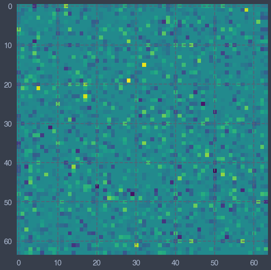

```python
from matplotlib.pyplot import imshow
import matplotlib.pylab as plt

# Let us reshape the coeffs
log_reg.densify()
coeffs_dense =  log_reg.coef_
type(coeffs_dense)
coeffs_dense = coeffs_dense.reshape(10, 1, 4096)
coeffs_dense = coeffs_dense.reshape(10, 64, 64)

imshow(coeffs_dense[0])
```

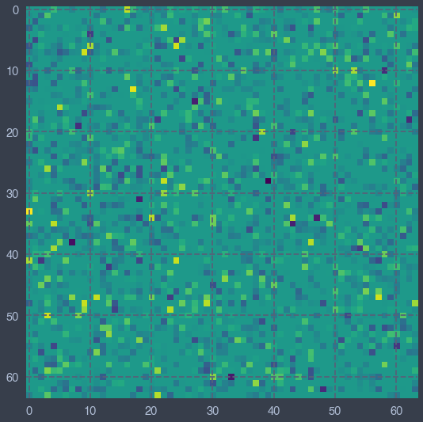

```python
imshow(coeffs_dense[1])
```

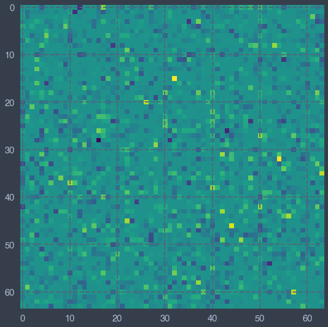

```python
imshow(coeffs_dense[9])
```

Let us now run tSNE on these weights to find out if we see a pattern

```python
from sklearn.manifold import TSNE
from utils import plot_with_labels
tsne = TSNE(n_components=2, perplexity=30.0, n_iter=50000, init="pca")
# let's generate some names for the classes because we are not sure who they belong to
labels = [x for x in range(10)]
embeddings = tsne.fit_transform(log_reg.coef_)
```

Note that, the labels in the plot below may or may not correspond to the digits 0 to 10. The logistic regression has definitely learned specific properties of the classes seeing how far apart they are in a low dimensional space.

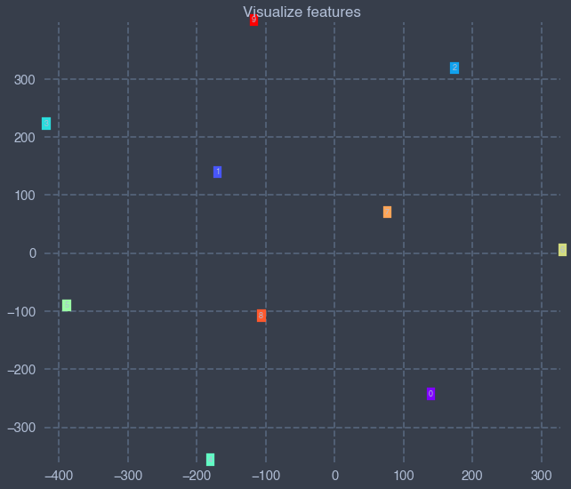

```python
plot_with_labels(embeddings, labels)
```

Let us look at prediction accuracy of this model. We will use `classification_report` function from `sklearn.metrics`

```python
from sklearn.metrics import classification_report
from utils import test_classifier
# evaluate predictions for the model
preds = test_classifier("log_reg", dataset="alexnet")
# get test data
test_features, test_labels = get_stored_dataset("alexnet", train=False)
rep = classification_report(test_labels, preds)
print(rep)
```

```
reading from local directory
reading from local directory
reading from local directory
reading from local directory
              precision    recall  f1-score   support

           0       0.96      0.98      0.97       980
           1       0.96      0.99      0.98      1135
           2       0.94      0.93      0.94      1032
           3       0.94      0.95      0.94      1010
           4       0.97      0.97      0.97       982
           5       0.93      0.91      0.92       892
           6       0.98      0.95      0.97       958
           7       0.95      0.97      0.96      1028
           8       0.97      0.97      0.97       974
           9       0.98      0.95      0.97      1009

    accuracy                           0.96     10000
   macro avg       0.96      0.96      0.96     10000
weighted avg       0.96      0.96      0.96     10000
```

The average accuracy for the model is around 96%. If we were training a state of the art model that we hope would beat all current models, the obviously that would require more rigor.

Now, we run similar prediction reports for all other logistic regression models.

```python
def get_classification_report(model_name, dataset_name):
    # evaluate predictions for the model
    preds = test_classifier(model_name, dataset=dataset_name)
    # get test data
    test_features, test_labels = get_stored_dataset(dataset_name, train=False)
    rep = classification_report(test_labels, preds)
    print(rep)
```

#### Logistic Regression - VGG16

```python
get_classification_report("log_reg", "vgg16")
```

```
reading from local directory
reading from local directory
reading from local directory
reading from local directory
              precision    recall  f1-score   support

           0       0.96      0.98      0.97       980
           1       0.96      0.99      0.97      1135
           2       0.96      0.95      0.95      1032
           3       0.94      0.95      0.95      1010
           4       0.95      0.97      0.96       982
           5       0.95      0.93      0.94       892
           6       0.97      0.94      0.96       958
           7       0.97      0.95      0.96      1028
           8       0.96      0.97      0.97       974
           9       0.97      0.93      0.95      1009

    accuracy                           0.96     10000
   macro avg       0.96      0.96      0.96     10000
weighted avg       0.96      0.96      0.96     10000
```

#### Logistic Regression - ResNet

```python
get_classification_report("log_reg", "resnet")
```

```
reading from local directory
reading from local directory
reading from local directory
reading from local directory
              precision    recall  f1-score   support

           0       0.97      0.99      0.98       980
           1       0.99      0.99      0.99      1135
           2       0.95      0.95      0.95      1032
           3       0.96      0.96      0.96      1010
           4       0.97      0.99      0.98       982
           5       0.96      0.95      0.96       892
           6       0.97      0.97      0.97       958
           7       0.95      0.97      0.96      1028
           8       0.97      0.97      0.97       974
           9       0.97      0.95      0.96      1009

    accuracy                           0.97     10000
   macro avg       0.97      0.97      0.97     10000
weighted avg       0.97      0.97      0.97     10000
```

#### Logistic Regression - Wavelet scattering

```python
get_classification_report("log_reg", "scattering")
```

```
reading from local directory
reading from local directory
reading from local directory
reading from local directory
              precision    recall  f1-score   support

           0       0.99      0.99      0.99       980
           1       0.98      1.00      0.99      1135
           2       0.98      0.99      0.98      1032
           3       0.99      0.99      0.99      1010
           4       0.98      0.99      0.99       982
           5       0.98      0.99      0.99       892
           6       0.99      0.98      0.99       958
           7       0.98      0.98      0.98      1028
           8       0.99      0.98      0.98       974
           9       0.98      0.97      0.98      1009

    accuracy                           0.98     10000
   macro avg       0.99      0.98      0.98     10000
weighted avg       0.99      0.98      0.98     10000
```

## Random Forests

We will not be able to visualize random forest weights etc in the same fashion as that for logistic regression. We will thus only focus on prediction accuracy.

```python
rf = get_stored_model("random_forest", "alexnet")
print(rf)
```

```
reading from local directory
RandomForestClassifier(bootstrap=True, class_weight=None, criterion='gini',
                       max_depth=None, max_features='auto', max_leaf_nodes=None,
                       min_impurity_decrease=0.0, min_impurity_split=None,
                       min_samples_leaf=1, min_samples_split=2,
                       min_weight_fraction_leaf=0.0, n_estimators=100,
                       n_jobs=None, oob_score=False, random_state=None,
                       verbose=5, warm_start=False)
```

#### Random Forest - AlexNet

```python
get_classification_report("random_forest", "alexnet")
```

```
reading from local directory
reading from local directory
reading from local directory
```

```
[Parallel(n_jobs=1)]: Using backend SequentialBackend with 1 concurrent workers.
[Parallel(n_jobs=1)]: Done   1 out of   1 | elapsed:    0.1s remaining:    0.0s
[Parallel(n_jobs=1)]: Done   2 out of   2 | elapsed:    0.1s remaining:    0.0s
[Parallel(n_jobs=1)]: Done   3 out of   3 | elapsed:    0.1s remaining:    0.0s
[Parallel(n_jobs=1)]: Done   4 out of   4 | elapsed:    0.2s remaining:    0.0s
[Parallel(n_jobs=1)]: Done 100 out of 100 | elapsed:    1.2s finished
```

```
reading from local directory
              precision    recall  f1-score   support

           0       0.96      0.97      0.96       980
           1       0.99      0.99      0.99      1135
           2       0.90      0.92      0.91      1032
           3       0.90      0.91      0.90      1010
           4       0.93      0.97      0.95       982
           5       0.90      0.88      0.89       892
           6       0.96      0.94      0.95       958
           7       0.96      0.94      0.95      1028
           8       0.96      0.93      0.94       974
           9       0.96      0.94      0.95      1009

    accuracy                           0.94     10000
   macro avg       0.94      0.94      0.94     10000
weighted avg       0.94      0.94      0.94     10000
```

#### Random Forest - VGG16

```python
get_classification_report("random_forest", "vgg16")
```

```
reading from local directory
reading from local directory
reading from local directory
```

```
[Parallel(n_jobs=1)]: Using backend SequentialBackend with 1 concurrent workers.
[Parallel(n_jobs=1)]: Done   1 out of   1 | elapsed:    0.0s remaining:    0.0s
[Parallel(n_jobs=1)]: Done   2 out of   2 | elapsed:    0.0s remaining:    0.0s
[Parallel(n_jobs=1)]: Done   3 out of   3 | elapsed:    0.0s remaining:    0.0s
[Parallel(n_jobs=1)]: Done   4 out of   4 | elapsed:    0.1s remaining:    0.0s
[Parallel(n_jobs=1)]: Done 100 out of 100 | elapsed:    0.9s finished
```

```
reading from local directory
              precision    recall  f1-score   support

           0       0.91      0.97      0.94       980
           1       0.98      0.98      0.98      1135
           2       0.89      0.91      0.90      1032
           3       0.90      0.93      0.91      1010
           4       0.89      0.94      0.92       982
           5       0.89      0.85      0.87       892
           6       0.95      0.92      0.94       958
           7       0.93      0.90      0.92      1028
           8       0.94      0.93      0.94       974
           9       0.94      0.89      0.91      1009

    accuracy                           0.92     10000
   macro avg       0.92      0.92      0.92     10000
weighted avg       0.92      0.92      0.92     10000
```

#### Random Forest - ResNet

```python
get_classification_report("random_forest", "resnet")
```

```
reading from local directory
reading from local directory
reading from local directory
```

```
[Parallel(n_jobs=1)]: Using backend SequentialBackend with 1 concurrent workers.
[Parallel(n_jobs=1)]: Done   1 out of   1 | elapsed:    0.0s remaining:    0.0s
[Parallel(n_jobs=1)]: Done   2 out of   2 | elapsed:    0.0s remaining:    0.0s
[Parallel(n_jobs=1)]: Done   3 out of   3 | elapsed:    0.0s remaining:    0.0s
[Parallel(n_jobs=1)]: Done   4 out of   4 | elapsed:    0.0s remaining:    0.0s
```

```
reading from local directory
              precision    recall  f1-score   support

           0       0.96      0.98      0.97       980
           1       0.99      0.99      0.99      1135
           2       0.93      0.92      0.93      1032
           3       0.94      0.96      0.95      1010
           4       0.94      0.98      0.96       982
           5       0.93      0.92      0.93       892
           6       0.96      0.96      0.96       958
           7       0.95      0.95      0.95      1028
           8       0.97      0.95      0.96       974
           9       0.97      0.93      0.95      1009

    accuracy                           0.95     10000
   macro avg       0.95      0.95      0.95     10000
weighted avg       0.96      0.95      0.95     10000
```

```
[Parallel(n_jobs=1)]: Done 100 out of 100 | elapsed:    0.5s finished
```

#### Random Forest - Wavelet Scattering

```python
get_classification_report("random_forest", "scattering")
```

```
reading from local directory
reading from local directory
reading from local directory
```

```
[Parallel(n_jobs=1)]: Using backend SequentialBackend with 1 concurrent workers.
[Parallel(n_jobs=1)]: Done   1 out of   1 | elapsed:    0.0s remaining:    0.0s
[Parallel(n_jobs=1)]: Done   2 out of   2 | elapsed:    0.0s remaining:    0.0s
[Parallel(n_jobs=1)]: Done   3 out of   3 | elapsed:    0.0s remaining:    0.0s
[Parallel(n_jobs=1)]: Done   4 out of   4 | elapsed:    0.0s remaining:    0.0s
[Parallel(n_jobs=1)]: Done 100 out of 100 | elapsed:    0.8s finished
```

```
reading from local directory
              precision    recall  f1-score   support

           0       0.98      0.99      0.99       980
           1       0.99      0.99      0.99      1135
           2       0.98      0.99      0.98      1032
           3       0.98      0.99      0.98      1010
           4       0.98      0.99      0.99       982
           5       0.99      0.98      0.98       892
           6       0.99      0.98      0.98       958
           7       0.97      0.98      0.98      1028
           8       0.98      0.98      0.98       974
           9       0.99      0.96      0.97      1009

    accuracy                           0.98     10000
   macro avg       0.98      0.98      0.98     10000
weighted avg       0.98      0.98      0.98     10000
```

```python
from sklearn.metrics import balanced_accuracy_score
def get_balanced_accuracy_score(model_name, dataset_name):
       # evaluate predictions for the model
    preds = test_classifier(model_name, dataset=dataset_name)
    # get test data
    test_features, test_labels = get_stored_dataset(dataset_name, train=False)
    score = balanced_accuracy_score(test_labels, preds)
    print("{} {} accuracy: {}".format(model_name, dataset_name, score))
```

```python
get_balanced_accuracy_score("log_reg", "alexnet")
get_balanced_accuracy_score("log_reg", "vgg16")
get_balanced_accuracy_score("log_reg", "resnet")
get_balanced_accuracy_score("log_reg", "scattering")

get_balanced_accuracy_score("random_forest", "alexnet")
get_balanced_accuracy_score("random_forest", "vgg16")
get_balanced_accuracy_score("random_forest", "resnet")
get_balanced_accuracy_score("random_forest", "scattering")
```

```
reading from local directory
reading from local directory
reading from local directory
reading from local directory
log_reg alexnet accuracy: 0.958397377218256
reading from local directory
reading from local directory
reading from local directory
reading from local directory
log_reg vgg16 accuracy: 0.9570058472359039
reading from local directory
reading from local directory
reading from local directory
reading from local directory
log_reg resnet accuracy: 0.9676573213192252
reading from local directory
reading from local directory
reading from local directory
reading from local directory
log_reg scattering accuracy: 0.9849363381990764
reading from local directory
reading from local directory
reading from local directory
```

```
[Parallel(n_jobs=1)]: Using backend SequentialBackend with 1 concurrent workers.
[Parallel(n_jobs=1)]: Done   1 out of   1 | elapsed:    0.0s remaining:    0.0s
[Parallel(n_jobs=1)]: Done   2 out of   2 | elapsed:    0.0s remaining:    0.0s
[Parallel(n_jobs=1)]: Done   3 out of   3 | elapsed:    0.0s remaining:    0.0s
[Parallel(n_jobs=1)]: Done   4 out of   4 | elapsed:    0.0s remaining:    0.0s
[Parallel(n_jobs=1)]: Done 100 out of 100 | elapsed:    0.8s finished
```

```
reading from local directory
random_forest alexnet accuracy: 0.9393313488150652
reading from local directory
reading from local directory
reading from local directory
```

```
[Parallel(n_jobs=1)]: Using backend SequentialBackend with 1 concurrent workers.
[Parallel(n_jobs=1)]: Done   1 out of   1 | elapsed:    0.0s remaining:    0.0s
[Parallel(n_jobs=1)]: Done   2 out of   2 | elapsed:    0.0s remaining:    0.0s
[Parallel(n_jobs=1)]: Done   3 out of   3 | elapsed:    0.0s remaining:    0.0s
[Parallel(n_jobs=1)]: Done   4 out of   4 | elapsed:    0.0s remaining:    0.0s
[Parallel(n_jobs=1)]: Done 100 out of 100 | elapsed:    0.8s finished
```

```
reading from local directory
random_forest vgg16 accuracy: 0.9229875912877249
reading from local directory
reading from local directory
reading from local directory
```

```
[Parallel(n_jobs=1)]: Using backend SequentialBackend with 1 concurrent workers.
[Parallel(n_jobs=1)]: Done   1 out of   1 | elapsed:    0.0s remaining:    0.0s
[Parallel(n_jobs=1)]: Done   2 out of   2 | elapsed:    0.0s remaining:    0.0s
[Parallel(n_jobs=1)]: Done   3 out of   3 | elapsed:    0.0s remaining:    0.0s
[Parallel(n_jobs=1)]: Done   4 out of   4 | elapsed:    0.0s remaining:    0.0s
[Parallel(n_jobs=1)]: Done 100 out of 100 | elapsed:    0.6s finished
```

```
reading from local directory
random_forest resnet accuracy: 0.9543914458260427
reading from local directory
reading from local directory
reading from local directory
```

```
[Parallel(n_jobs=1)]: Using backend SequentialBackend with 1 concurrent workers.
[Parallel(n_jobs=1)]: Done   1 out of   1 | elapsed:    0.0s remaining:    0.0s
[Parallel(n_jobs=1)]: Done   2 out of   2 | elapsed:    0.0s remaining:    0.0s
[Parallel(n_jobs=1)]: Done   3 out of   3 | elapsed:    0.0s remaining:    0.0s
[Parallel(n_jobs=1)]: Done   4 out of   4 | elapsed:    0.0s remaining:    0.0s
[Parallel(n_jobs=1)]: Done 100 out of 100 | elapsed:    0.8s finished
```

```
reading from local directory
random_forest scattering accuracy: 0.9821851756775063
```

# Performance

We see from the performance tables below that Logistic Regression trained on features extracted from Wavelet Scattering Transform have better results than Random Forest by a narrow margin. The input features is high dimensional for both Logistic Regression and Random Forest, but we can say that logistic regression is better able to introduce some sparsity in the data thereby avoiding overfitting and generalizing very well. Random Forests are also very good at handling high dimensional data, rapidly getting rid of features that don't contribute to information gain while growing a tree or a branch, thus it is hard to point out an exact reason why logistic regression generalized better.

|  | Logistic Regression | Random Forest |
| --- | --- | --- |
| AlexNet Features | 95.84% | 93.93% |
| VGG16 Features | 95.70% | 92.30% |
| ResNet Features | 96.77% | 95.44% |
| Wavelet Scattering Features | 98.49% | 98.22% |

# Conclusion

In conclusion, we have perform several tests to address and compare Logistic Regression and Random Forest. However, these test are only performed on 1 training and test data pair, which is also very important. Generally, it is better to mix a given test data set with a training data set, and then randomly divide it into training and test data for a specific experiment. Running multiple such experiments and obtaining a dispersion of accuracy values is important to consider the dependence of generalization accuracy on a particular training/test set. The usual practice is to draw a box plot of the accuracy values of multiple experiments for each model-data set pair, and then compare the medians of these values. What I have done in this report is just a fairly soft version of what I have described. Deformed images can also be added to the data set, and experiments can also be performed on this.

It is also important to note that although the wavelet scattering transform provides some theoretical guarantee for the invariance of deformation, deep CNN does not provide any such guarantee. CNN has been designed and fine-tuned for each application to suit that specific application. In this case, the pre-trained CNN used will be pre-trained on the ImageNet dataset that is not completely "similar" to MNIST. This may also be the reason for the lagging performance of models trained with those CNN functions.